# Statistical analysis of water discharge of surface streams

Large amounts of historical surface water data are available from the United States Geological Survey (USGS) at https://waterdata.usgs.gov/nwis The goal of the project is to retrieve samples from the web interface manually, and then later automate the process by calling the web service as described at https://help.waterdata.usgs.gov/faq/automated-retrievals.

## Excercise 1

For the purposes of the current excercises, select a stream from a rainy area with relatively small discharge so that the effect of short but strong storms is visible. Good choices are small rivers from the north-eastern US, e.g. site 01589440. Retrieve at least 10 years of data.

#### I've manually downloaded it for the site #01589440.

```
01471875-data		  site3		Waterlevel-statistics-empty.ipynb
data			  site4		Waterlevel-statistics-solutions.html
how-to-download-data.txt  usgs-1.ipynb	Waterlevel-statistics-solutions.ipynb
site1			  usgs-2.html
site2			  usgs-2.ipynb
```

## Excercise 2

Load the downloaded data file into the processing environment paying attention to handling time stamps and perfoming the necessary data type conversions. Converting dates to floating point numbers such as unix time stamp or julian date usually makes handling time series easier. Plot the data for a certain interval to show that the effect of storms is clearly visible.

```
(413518, 8)
```

|  | agency_cd | site_no | datetime | tz_cd | 69744_00060 | 69744_00060_cd | 69745_00065 | 69745_00065_cd |
| --- | --- | --- | --- | --- | --- | --- | --- | --- |
| 0 | USGS | 1589440 | 2007-02-01 00:00 | EST | 27.0 | A:[91] | NaN | NaN |
| 1 | USGS | 1589440 | 2007-02-01 00:15 | EST | 27.0 | A:[91] | NaN | NaN |
| 2 | USGS | 1589440 | 2007-02-01 00:30 | EST | 27.0 | A:[91] | NaN | NaN |

```
array(['27.0', '28.0', '29.0', ..., '56.1', '48.8', 'Ice'], dtype=object)
```

```
datetime         0
discharge    17320
dtype: int64
```

```
((396198, 2), (413518, 2))
```

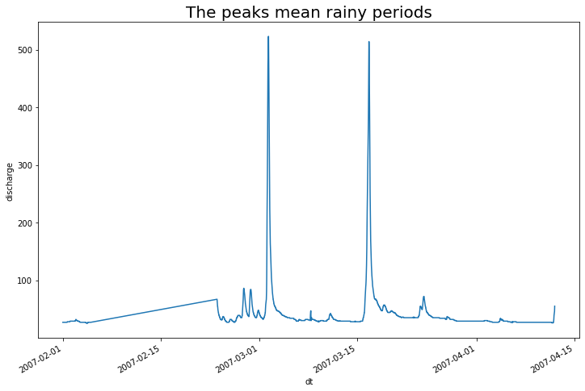

## Excercise 3

Plot the histogram of water discharge values. Fit the data with an appropriate distribution function and bring arguments in favor of the choice of function.

```
count    396198.000000
mean         36.760202
std         111.418725
min          -1.000000
1%            4.200000
5%            8.580000
25%          14.500000
50%          21.800000
75%          33.300000
95%          80.900000
99%         298.000000
max        7490.000000
Name: discharge, dtype: float64
```

```
7490.0
```

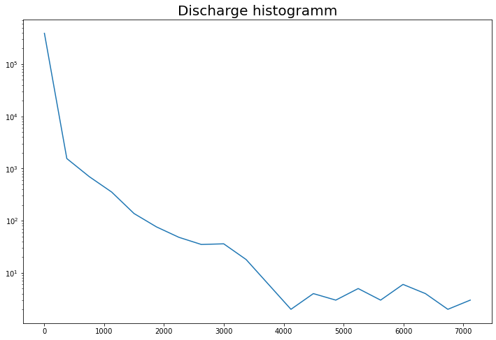

```
array([ 3.05445858, 43.68841935, 20.40064444])
```

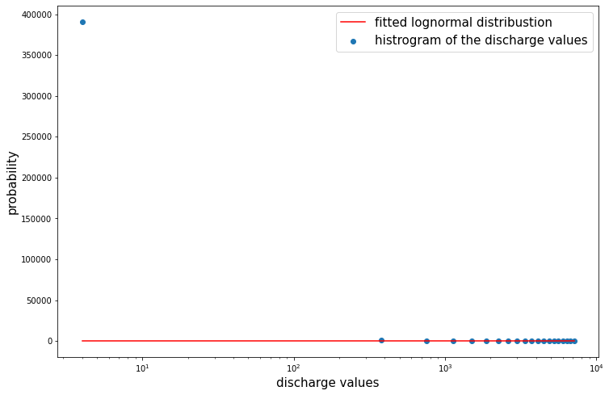

## Excercise 4

In case of small streams, storms and passing weather fronts with rain can significantly increase water discharge on a short time scale. Develop a simple algorithm to detect rainy events in the data. Plot the original time series and mark rainy events.

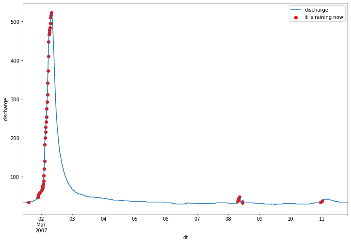

## Excercise 5

Water discharge increases significantly during rain producing maxima in the time series. Plot the distribution of maximum values and fit with an appropriate function. Bring arguments to support the choice of probabilistic model.

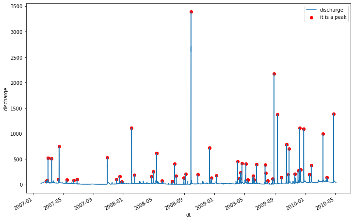

```
count     420.000000
mean      451.215952
std       718.438189
min        51.200000
1%         58.500000
5%         68.900000
25%       113.000000
50%       196.000000
75%       511.500000
95%      1380.500000
99%      3489.100000
max      7490.000000
Name: discharge, dtype: float64
```

```
array([  1.79387391,  59.26806024, 136.50888254])
```

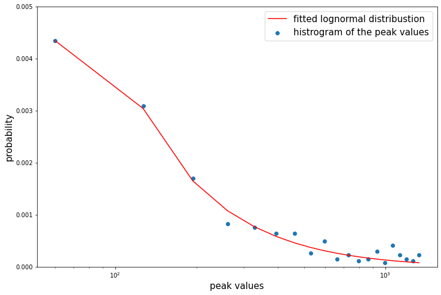

## Excercise 6

Once rainy events are detected, plot the distribution of the length of sunny intervals between rains. Fit the distribution with an appropriate function.

#### I assume the sun shines when it does not raining. Even at 2 AM.

```
(0.010416666666666666, 65.11458333333333)
```

```
7
```

```
array([-0.00925352, -0.69909326,  0.09509078])
```

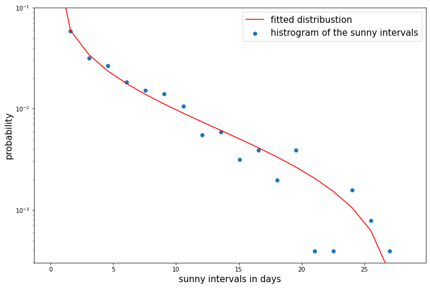

## Excercise 7

What is the maximum of water discharge in an arbitrarily chosen period of one year? Calculate the maximum of water discharge due to rain in a rolling window of 1 year, plot its distribution and fit with an appropriate function.

```
35040.0
```

```
(754.0, 7490.0)
```

```
array([9.57516474e-01, 3.42710326e+02, 1.56570870e+03])
```

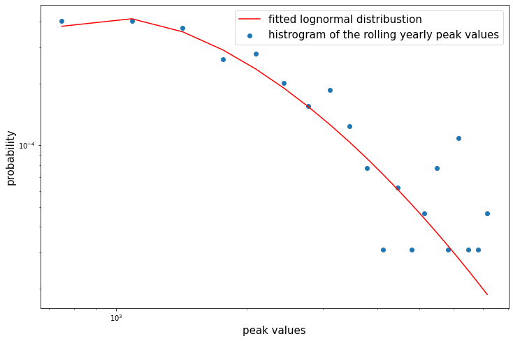

## Excercise 8

How many time does it rain in a month? Calculate and plot the distribution and fit with an appropriate function.

|  | datetime | discharge | dt | is_raining | is_peak | year_month |
| --- | --- | --- | --- | --- | --- | --- |
| 0 | 2007-02-01 00:00 | 27.0 | 2007-02-01 00:00:00 | False | False | 2007-02 |
| 1 | 2007-02-01 00:15 | 27.0 | 2007-02-01 00:15:00 | False | False | 2007-02 |
| 2 | 2007-02-01 00:30 | 27.0 | 2007-02-01 00:30:00 | False | False | 2007-02 |

```
array([2.44350531, 2.12130439])
```

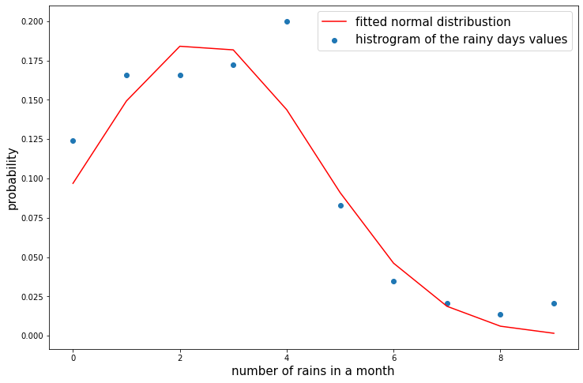

## Excercise 9

Find the measuring station you used in the excercises above on the map. Find another measurement station about 100-200 miles from it and download the data. Try to estimate the typical time it takes for weather fronts to travel the distance between the two measuring stations.

Original one: #01589440 is in Baltimore

New one: #01450500 is in Carbon County, which is around 150 miles from Baltimore

|  | datetime | discharge |
| --- | --- | --- |
| 1 | 2007-03-03 00:00 | 806.0 |
| 2 | 2007-03-03 00:15 | 762.0 |
| 3 | 2007-03-03 00:30 | 733.0 |

```
412
```

```
344
```

|  | day | datetime_x | datetime_y | dt_x | dt_y |
| --- | --- | --- | --- | --- | --- |
| 0 | 2007-04-12 | 2007-04-12 14:15 | 2007-04-12 06:15 | 2007-04-12 14:15:00 | 2007-04-12 06:15:00 |
| 1 | 2007-04-12 | 2007-04-12 14:15 | 2007-04-12 06:30 | 2007-04-12 14:15:00 | 2007-04-12 06:30:00 |
| 2 | 2007-10-27 | 2007-10-27 23:15 | 2007-10-27 08:15 | 2007-10-27 23:15:00 | 2007-10-27 08:15:00 |
| 3 | 2008-02-01 | 2008-02-01 21:45 | 2008-02-01 17:00 | 2008-02-01 21:45:00 | 2008-02-01 17:00:00 |
| 4 | 2008-02-01 | 2008-02-01 21:45 | 2008-02-01 17:15 | 2008-02-01 21:45:00 | 2008-02-01 17:15:00 |

```
array([21286.24131581, 15085.58410793])
```

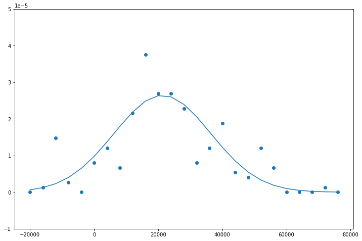

## Well se can say that the difference is 21000 $\pm$ 15000 seconds. Which is 5-6 hours.They are 150 miles from each other.

#### Rain cloud speed is around 40kmph this way.